# Data Science for Business Project: Bank Marketing

Sabirova Aidai

2017-02-15

# Data Cleaning and Exploratory Analysis

### The dataset

The dataset was downloaded from UCI Machine Learning Repository. The data is related with direct marketing campaigns (phone calls) of a Portuguese banking institution. The classification goal is to predict if the client will subscribe a term deposit (variable y). The original labeled data set has N=45211 observations with 17 variables, and later splitted into training and test sets.

##### Input variables:

###### bank client data:

1 - age (numeric)

2 - job : type of job (categorical: ‘admin.’,‘blue-collar’,‘entrepreneur’,‘housemaid’,‘management’,‘retired’,‘self-employed’,‘services’,‘student’,‘technician’,‘unemployed’,‘unknown’)

3 - marital : marital status (categorical: ‘divorced’,‘married’,‘single’,‘unknown’; note: ‘divorced’ means divorced or widowed)

4 - education (categorical: ‘basic.4y’,‘basic.6y’,‘basic.9y’,‘high.school’,‘illiterate’,‘professional.course’,‘university.degree’,‘unknown’)

5 - default: has credit in default? (categorical: ‘no’,‘yes’,‘unknown’)

6 - housing: has housing loan? (categorical: ‘no’,‘yes’,‘unknown’)

7 - loan: has personal loan? (categorical: ‘no’,‘yes’,‘unknown’)

###### related with the last contact of the current campaign:

8 - contact: contact communication type (categorical: ‘cellular’,‘telephone’)

9 - month: last contact month of year (categorical: ‘jan’, ‘feb’, ‘mar’, …, ‘nov’, ‘dec’)

11 - duration: last contact duration, in seconds (numeric). Important note: this attribute highly affects the output target (e.g., if duration=0 then y=‘no’). Yet, the duration is not known before a call is performed. Also, after the end of the call y is obviously known. Thus, this input should only be included for benchmark purposes and should be discarded if the intention is to have a realistic predictive model.

###### other attributes:

12 - campaign: number of contacts performed during this campaign and for this client (numeric, includes last contact)

13 - pdays: number of days that passed by after the client was last contacted from a previous campaign (numeric; 999 means client was not previously contacted)

14 - previous: number of contacts performed before this campaign and for this client (numeric)

##### Output variable:

21 - y - has the client subscribed a term deposit? (binary: ‘yes’,‘no’)

### Loading the dataset

To make sure that the results are reproducible I set the random seed. Loaded the libraries that will help to run the codes throughout the analysis.

```r
set.seed(1234)
library(descr)
library(data.table)
library(ggplot2)
library(randomForest)
library(gbm)
library(nnet)
library(ROCR)
library(knitr)
library(pander)
```

The dataset is stored in a csv file, where the separators are semicolons. The dataframe where the dataset is loaded named as data.

```r
data<-read.csv("bank-full.csv",sep=';')
```

### Descriptive Statistics

This part will give some basic description and understanding of the variables in the dataset.

#### Age distribution

Age distribution of the data set is unimodal at 30 to 35. The distribution of age is skewed with longer right tail.

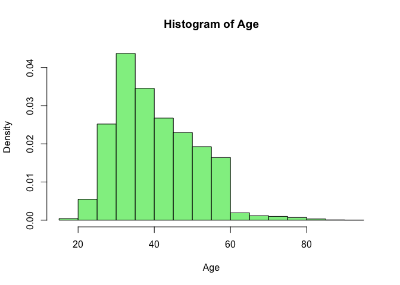

```r
hist(data$age, col = "light green", main = "Histogram of Age", xlab = "Age", freq = FALSE)
```

#### Month distribution

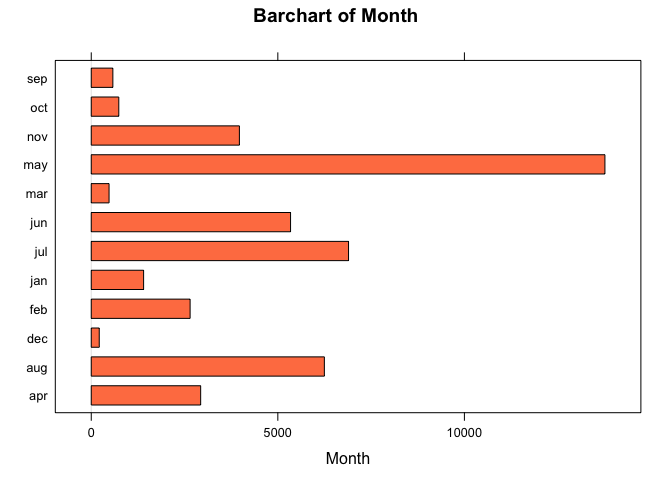

```r
barchart(data$month, col = "coral", main = "Barchart of Month", xlab = "Month", freq = FALSE)
```

The barchart of month distribution shows that most clients were last contacted in May.

#### Distribution of outcome of the previous campaign

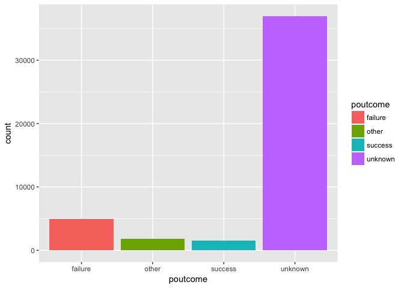

```r
ggplot(data)+geom_bar(aes(x=poutcome,fill=poutcome))
```

The distribution shows that most of the observations do not have information about the outcome of the previous campaign. To understand what caused so many unknowns in the outcome of the previos campaign, I created a table to see the relationship between number of contacts performed before this campaign and for this client and outcome of the previous marketing campaign. The reason why there are so many unknown results is because bank has never contacted those clients before. So we may assume that they are new customers.

```r
table(data$poutcome,data$previous>0)
```

```
##
##           FALSE  TRUE
##   failure     0  4901
##   other       0  1840
##   success     0  1511
##   unknown 36954     5
```

#### Probability of the campaign success considering marital and job status

The data table was created to aid finding the probability for every job and marriage pair. The graph below shows tha single students and who divorced and retired are most likely to subscribe a term deposit provided by the bank.

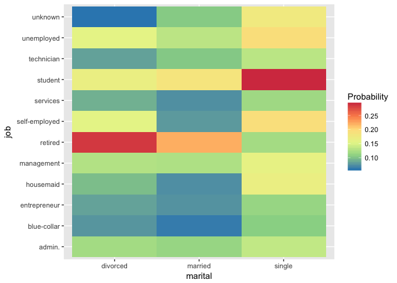

```r
data<-data.table(data)
ggplot(data[,mean(as.numeric(y)-1),by=.(marital,job)],aes(x=marital,y=job))+geom_tile(aes(fill=V1))+scale_fill_distiller(palette="Spectral","Probability")
```

```r
sum(data$previous>10)
```

```
## [1] 294
```

There are only 294 observations in the data that were contacted by the bank more than 10 times.

#### Probability of subscribing the term deposit based on number of contacts performed before this campaign and for this client

The graph below demonstrates that the more bank contact the clients in the past, the more likely clients sign up for term deposit.

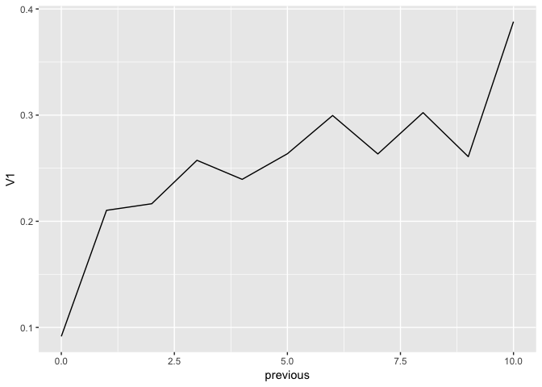

```r
ggplot(data[previous<=10,mean(as.numeric(y)-1),by=previous][order(previous)])+geom_line(aes(x=previous,y=V1))
```

## Machine Learning

### Modeling

Since the dataset was relatively clean, there was no need for me to create clean dataset. So there was no problem in running different models. The goal is to find the model that fits the data the best. I used three different models Random Forest ensemble learning (RF), Gradient Boosting Machine (GBM) and Neural Networks (NN) to predict and see how they perform. AUC will be used to measure predictive modeling accuracy.

##### Splitting the data

The dataset was splitted into train and test sets, where 60% of the dataset will be assigned to be a train set and other 40% as test set. We have 27126 observations with 17 variables as train dataset, and 18085 observations with 17 variables as test dataset.

```r
N<-nrow(data)
id<-sample(1:N,0.6*N)
d_train<-data[id,]
d_test<-data[-id,]
```

### Random Forest

The values of Random Forest model are:  
Number of trees (ntrees): 500.  
Probability of clients to say ‘yes’ to subscribe the term deposit: predict(md, d_test, type = “prob”)[,“yes”].  
Threshold of the probability of clients clients saying ‘yes’: phat>0.5,1,0.  
So if the probability is 0 or less than or equal to 0.5, the client will not sign up, if probability equals 1, then he will sign up for the term deposit offered by the bank.

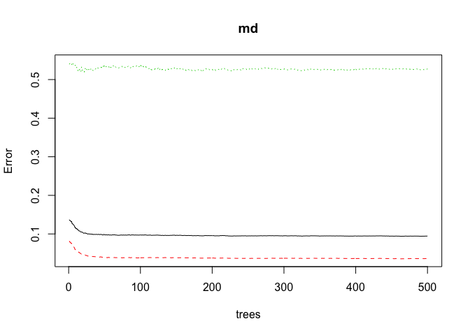

```r
md <- randomForest(y ~ ., data = d_train, ntree = 500)

plot(md)
```

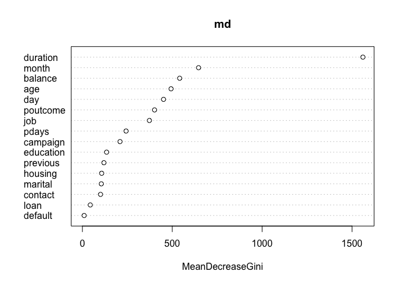

```r
varImpPlot(md)
```

```r
phat <- predict(md, d_test, type = "prob")[,"yes"]
```

VarImp is used to demonstrate the variables that are important in predicting the outcome of banking marketing. Duration has the highest importance as well as month and balance has strong effect on predicting the outcome.

```r
pander(table(ifelse(phat>0.5,1,0), d_test$y))
```

|  | no | yes |
| --- | --- | --- |
| **0** | 15403 | 1061 |
| **1** | 615 | 1006 |

```r
rocr_obj <- prediction(phat, d_test$y)
```

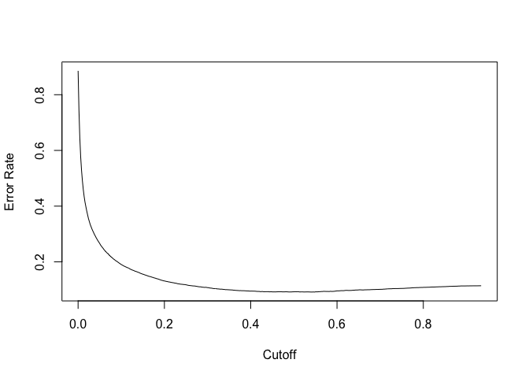

```r
plot(performance(rocr_obj, "err"))
```

The AUC is 0.9346989.

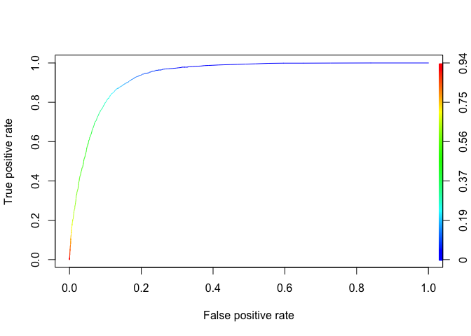

ROC Curve

```r
plot(performance(rocr_obj, "tpr", "fpr"), colorize=TRUE)
```

### GBM

Data: First we changed y variable in train and test sets to the numbers.  
We use 1 to denote *yes* in the y variable and 0 to denote *no* in the y variable.  
Distribution: Since the outcome of the marketing is binary 0 or 1, we use “bernoulli” distribution.  
The total number of trees to fit (n.trees): 300.  
The maximum depth of variable interactions (interaction.depth): 10.  
A shrinkage parameter applied to each tree in the expansion (shrinkage): 0.05.

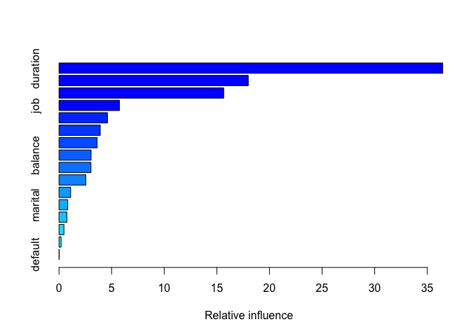

```
##                 var     rel.inf
## duration   duration 36.46787990
## month         month 17.98622960
## poutcome   poutcome 15.65138843
## job             job  5.74322458
## day             day  4.60735366
## age             age  3.91998648
## pdays         pdays  3.62241349
## balance     balance  3.04804355
## contact     contact  3.03772098
## housing     housing  2.55073721
## campaign   campaign  1.10665575
## marital     marital  0.82723694
## education education  0.75081609
## previous   previous  0.46890004
## loan           loan  0.19922857
## default     default  0.01218473
```

```r
d_train_ynum<-d_train
d_train_ynum$y <- ifelse(d_train_ynum$y=="yes",1,0)
d_test_ynum<-d_test
d_test_ynum$y <- ifelse(d_test_ynum$y=="yes",1,0)

md <- gbm(y ~ ., data = d_train_ynum, distribution = "bernoulli",
          n.trees = 300, interaction.depth = 10, shrinkage = 0.05)
summary(md)
```

```r
yhat <- predict(md, d_test, n.trees = 300)
```

In the graph above demonstrates the variables that affect the prediction when running GBM prediction model. The variable that has the highest effect on predicting whether a client is going to subscribe the term deposit that bank is marketing is duration.

```r
pander(table(ifelse(yhat>0,1,0), d_test$y))
```

|  | no | yes |
| --- | --- | --- |
| **0** | 15472 | 1048 |
| **1** | 546 | 1019 |

```r
rocr_obj <- prediction(yhat, d_test$y)
```

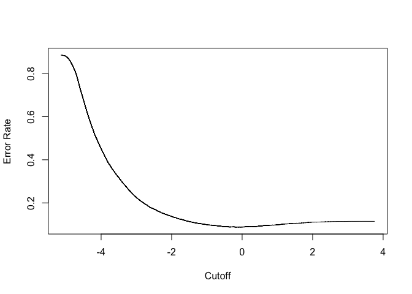

```r
plot(performance(rocr_obj, "err"))
```

The AUC is 0.937068

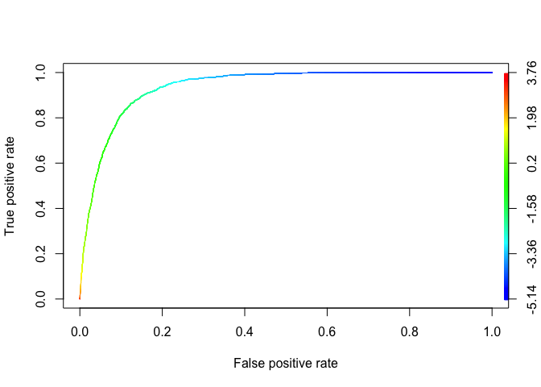

ROC Curve

```r
plot(performance(rocr_obj, "tpr", "fpr"), colorize=TRUE)
```

### Neural Networks

```r
nnhat <- predict(md, newdata = d_test)
```

```r
pander(table(ifelse(nnhat>0.5,1,0), d_test$y))
```

|  | no | yes |
| --- | --- | --- |
| **0** | 15325 | 993 |
| **1** | 693 | 1074 |

[figure not shown]

```r
plot(performance(rocr_obj, "err"))
```

The AUC is 0.9270502

[figure not shown]

ROC Curve

```r
plot(performance(rocr_obj, "tpr", "fpr"), colorize=TRUE)
```

# Conclusion

As AUC is measuring the performance of the prediction model, comparing AUC of RF, GBM and NN models, we can see that AUCs of these three models are almost the same, but GBM has the highest AUC of 0.937068. So if bank is doing marketing in the future, it can use GBM as predicting model because it has the highest accuracy.